# Figure 4 - Regional spread of Candid auris

Diana Proctor

5/17/2022

last updated: August 04 2023

*draft: submission to Nature, August 2023*

*Manuscript Title*: Fungal Candida auris and bacterial ESKAPE pathogens: Human skin as a reservoir for transmissible microbes and antibiotic resistance in nursing homes

*Authors*: Diana M. Proctor 1, Sarah E Sansom2, Clay Deming1, Sean Conlan1, Ryan A Blaustein1,3, Thomas K. Atkins1,4, NISC Comparative Sequencing Program5, Thelma Dangana2, Christine Fukuda2, Lahari Thotapalli2, Heidi H. Kong6, Michael Y. Lin2, Mary K. Hayden2+ and Julia A. Segre 1+

*Affiliations*:

1Microbial Genomics Section, Translational and Functional Genomics Branch, National Human Genome Research Institute, National Institutes of Health, Bethesda, MD 20892, USA

2 Department of Internal Medicine, Division of Infectious Diseases, Rush University Medical Center, Chicago, IL 60612, USA.

3 Current Address: Department of Nutrition and Food Science, University of Maryland, College Park, MD 20742, USA

4 Current Address: Department of Quantitative and Computational Biology, Princeton University, Princeton, NJ

5 NIH Intramural Sequencing Center, National Human Genome Research Institute, National Institutes of Health, Bethesda, MD 20892, USA.

6 Dermatology Branch, National Institute of Arthritis and Musculoskeletal and Skin Diseases, National Institutes of Health, Bethesda, MD 20892, USA

+Contributed equally

The input for this is the following files, generated using the mags.sh script:

1. 3_way_masked_adqia_masked.vcf.gz, snp calls, intersection of bctools, gatk, and freebayes
2. metadata_colors.csv, mapping file for the isolate genomes
3. longMatrixTreeDist_clean.csv, generated in chunk 7 subsetted down onto just our samples

This script will generate the following plots:

1. figure 4
2. supplementary figure 12

```r
library(knitr)
opts_chunk$set(fig.width=12, fig.height=8,
               echo=TRUE, warning=FALSE, message=FALSE, error = FALSE)
```

load libraries

```r
packages <- c("knitr",
              "vcfR",
              "ggplot2",
              "tidyverse",
              "colorspace",
              "scales",
              "ape",
              "ggtree",
              "Biostrings",
              "adegenet",
              "poppr",
              "pegas",
              "dendextend",
              "cowplot",
              "ggpubr",
              "ComplexHeatmap",
              "reshape2",
              "TreeDist",
              "phylogram",
              "cetcolor",
              "phylotools")
n <- length(packages) - sum(sapply(packages,require,character.only=TRUE))
```

### Figure 4A: make a phylogenetic tree of the candida auris isolate genomes

```r
#let's read in the phylogeny generated with IqTree
tre = ape::read.tree("~/Desktop/NATURE/Figure4/3_way_masked_adqia_masked.min4.phy.contree")


#let's read in the metadata
mydat = read.csv("~/Desktop/NATURE/Figure4/metadata_colors.csv") %>%
  dplyr::select(., c("rg", "color"))

#let's root this tree at the midpoint
tre2 = phytools::midpoint.root(tre)

#first we plot the tree
p1 = ggtree(tre2)+ theme_tree2() + geom_tiplab(as_ylab=TRUE, color='black', size=2)
new.labels = read.csv("~/Desktop/NATURE/Figure4/relabel_tree.csv")
#I modified this function ever so slightly. plot.tree is the work of Thomas Atkins.
#It plots the phylogenetic tree given as input using ggtree.
plot.tree <- function(tree, metadata) {
    # it will give a lot of messages about plotting the tree,
    # so we use suppressMessages
    suppressMessages(
        g <- ggtree(tree) + theme_tree2() + geom_tiplab(as_ylab=TRUE, color='black')
    )
    #if we have metadata, color the tips of the trees appropriately
    # https://yulab-smu.top/treedata-book/chapter7.html?q=%3C+#attach-operator
    if (!is.null(metadata)) {
        colors <- replace(metadata$color, metadata$color=="", "red")
        names(colors) <- colors
        g <- g %<+%
            data.frame(tip=metadata$rg, col=metadata$color) +
            geom_tiplab(as_ylab=TRUE, color='black', size=5) +
            geom_tippoint(aes(color=col), show.legend = FALSE) +
            scale_color_manual(values=colors, na.value="black")
    }
    return (g)
}

p2 = plot.tree(tree=tre2, metadata = mydat)
```

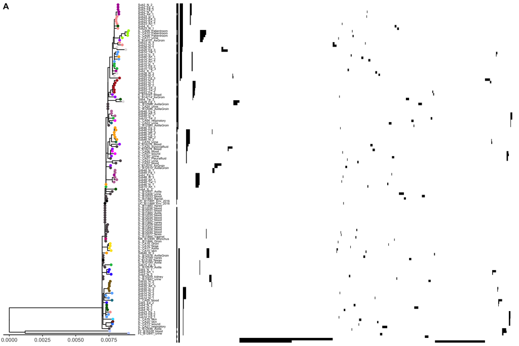

```r
# vcfR
consensus3way = read.vcfR("~/Desktop/NATURE/Figure4/3_way_masked_adqia_masked.vcf.gz", verbose=FALSE)
consensus3way <- addID(consensus3way) #765
gt <- extract.gt(consensus3way, element = "GT")

#get the tip labels
#these 2 lines are from Thomas Atkins, the summer intern extraordinaire
dd <- subset(fortify(tre2), isTip)
    order <- dd$label[order(dd$y, decreasing=T)]

#let's set no calls equal to 0
M = data.frame(t(gt))
M[is.na(M)] <- 0

#let's order the rows of the matrix based on the tree order
new_dataset <- M[match(order, rownames(M)), ]

M = data.matrix(new_dataset, rownames.force = NA)
names = rownames(M)


#let's make the SNP heatmap

p3 = Heatmap(M, cluster_rows = FALSE,show_row_dend = FALSE, show_column_dend = FALSE, row_names_gp = grid::gpar(fontsize = 0),
        show_column_names = FALSE, show_heatmap_legend = FALSE, col=c("white", "black"))

gb<-grid.grabExpr(draw(p3))
Fig4 = plot_grid(p2, gb, nrow = 1, rel_heights = c(1, 1), ncol = 2, rel_widths = c(1, 2), labels="A")
Fig4
```

```r
ggsave(Fig4, file="~/Desktop/NATURE/ABX_SAMPLES/Manuscript/Figure4.pdf", device="pdf", width = 7, height = 8)
```

### Supplementary Figure 12B: let’s look at within subject vs. between subject SNP distributions

```r
#read in the vcf, taken as an intersection of GATK, freebayes and bcftools
myvcf = read.vcfR("~/Desktop/NATURE/Figure4/3_way_masked_adqia_masked.vcf.gz")
```

[output not shown]

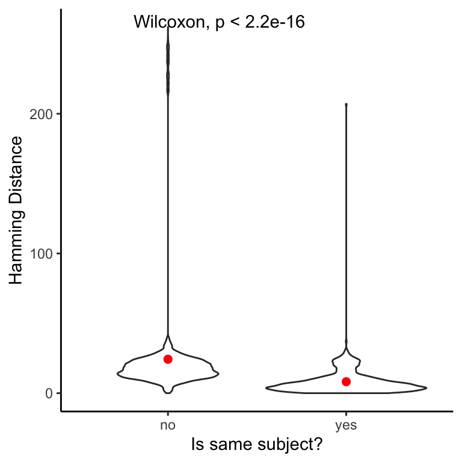

```r
#convert to genlight objects
vcf.x <- vcfR2genlight(myvcf)
ploidy(vcf.x) <- 1


#calculate hamming distancee
snpdist <- poppr::bitwise.dist(vcf.x, percent=FALSE) #calculates hamming distance
snpdist = data.frame(as.matrix(snpdist))

#let's bring in the sample map and annotate the rows
mapping_file = read.csv("~/Desktop/NATURE/Figure4/metadata_colors.csv") %>%
  dplyr::select(., c("rg", "Subject", "Sample", "Body.Site", "room"))

#melt the distance matrix
snpdist$sample1 = rownames(snpdist)
dfm = reshape2::melt(snpdist, id.vars=c("sample1"))
colnames(dfm)[2] = "sample2"

#now let's merge the mapping files with the melted distance matrix
map1 = mapping_file
colnames(map1) = c("sample1", "subject1", "J1", "site1", "room1")
map2 = mapping_file
colnames(map2) = c("sample2", "subject2", "J2", "site2", "room2")

#now let's add the sample metadata to the melted data frame
sampleDF = plyr::join(dfm, map1) %>%
        plyr::join(., map2)

#drop samples that are the same in sample1 and sample2
sampleDF1 = subset(sampleDF, sample1 != sample2)

#now let's annotate whether the sample1 and sample2 are from the same or different subjects
sampleDF1$is.same.subject = ifelse(sampleDF1$subject1==sampleDF1$subject2, "yes", "no")

mydf = subset(sampleDF1, sample1 != sample2) %>%
  subset(., is.same.subject %in% c("yes", "no"))


mysummary = doBy::summary_by(value~is.same.subject, FUN=c(mean, median, length), data=mydf)

SuppFig12B = ggplot(mydf, aes(is.same.subject, value)) +
  geom_violin() + theme_classic() + stat_compare_means()+ theme(legend.position = "none")  +
  stat_summary(fun = "mean",
               geom = "point",
               color = "red",
               size=2) + ylab("Hamming Distance")+ xlab("Is same subject?")

SuppFig12B
```

### Supplementary Figure 12C: make a plot of roomie comparisons

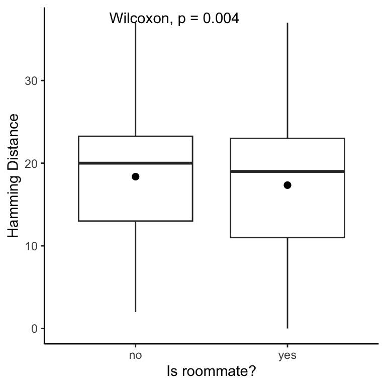

```r
#now let's annotate whether the sample1 and sample2 are from the same or different subjects
sampleDF1 = subset(sampleDF1, room1 %in% c("room1", "room2")) %>%
  subset(., room2 %in% c("room1", "room2"))
sampleDF1$is.roomie = ifelse(sampleDF1$room1==sampleDF1$room2, "yes", "no")
SuppFig12C = ggplot(sampleDF1, aes(is.roomie, value)) + theme_classic() + stat_compare_means() + geom_boxplot() +
  stat_summary(fun = "mean",
               geom = "point",
               color = "black",
               size=2) + ylab("Hamming Distance") + xlab("Is roommate?")


SuppFig12C
```

let’s look at the tree distance for individual subjects

```r
mytredist = adephylo::distTips(
  tre2,
  tips = "all",
  method =  "sumDD",
  useC = TRUE)

M = as.matrix(mytredist)
M[lower.tri(M)] <- NA
M = data.frame(M)
M$rows = rownames(M)
longM = reshape2::melt(M, id.vars="rows")
#write.csv(longM, file="~/Desktop/longMatrixTreeDist.csv") #subset on just our samples
df = read.csv("~/Desktop/NATURE/Figure4/longMatrixTreeDist_clean.csv")
df$Sub1 = stringr::str_sub(df$rows, 1, 5)
df$Sub2 = stringr::str_sub(df$variable, 1, 5)
df$is.same.sub = ifelse(df$Sub1==df$Sub2, "yes", "no")

sameSub = subset(df, is.same.sub=="yes")

p = ggplot(sameSub, aes(Sub1, value)) + geom_point()
SuppFig12A = ggplot(sameSub, aes(value)) +
  geom_histogram() +
  facet_wrap(~Sub1, scales="free_y", ncol=1) +
  theme_classic() + ylab("Count") + xlab("Tree Distance")

#let's save supplementary figure 12
Fig12C_Left = cowplot::plot_grid(SuppFig12A, labels="A")
Fig12C_Right = cowplot::plot_grid(SuppFig12B, SuppFig12C, ncol= 1, labels=c("B", "C"))
Fig12C = cowplot::plot_grid(Fig12C_Left, Fig12C_Right, ncol=2)
ggsave(Fig12C, file="~/Desktop/NATURE/ABX_SAMPLES/Manuscript/SupplementaryFigure12.png", device="png", width = 8, height = 10)
```